# Smoking Status, BMI, Life Expectancy, and Age in the Sanford Data Collaborative

TJ Liggett

January 2019

## Hypothesis

### There is no correlation between smoking status, BMI, and life expectancy. BMI and smoking status cannot be used to predict life expectancy.

## Methods

#### Statistical analyses were done utilizing the Sanford Data Collaborative Teaching Dataset (SDC), provided by Sanford Research. The SDC provided healthcare data for 155,143 Sanford patients. Of these patients, 151,480 were alive and 3,663 were deceased. While providing a variety of health factors, the SDC gave limited demographic information about patients to protect their privacy.

#### Analyses were made using four variables from the dataset (Age, Smoking Status, BMI, and Life Status). An assumption was made that the age of deceased individuals was their age at death, allowing for predictions about life expectancy. Smoking Status was a spectrum ranking from 1 to 10, with higher scores indicating higher smoking levels. Using these four given variables, two additional variables were created: Year of Birth and Average Smoking Status (per YOB). Year of Birth was generated by subtracting the age of living patients from the year 2018. As it is unclear when the dataset was submitted to Augustana and the birth dates of patients are unknown, this metric could be off by as much as a year. The mean smoking status of all patients born in each year was found to create the Average Smoking Status of a given birth year. Correlations between variables were found using Pearson’s product-moment correlation.

## RMD Code

#### Chunk 1: Initialized Database

```r
library(tidyverse)
setwd("C:/Users/trevo/OneDrive/Documents/COSC 219/sanford")
Sanford_data=read.csv("Sanford_Data_Collaborative_Teaching_DataSet.csv")
```

#### Chunk 2: Modifying data.Set Age and BMI as numeric factors. SmokingStatus was already set as numeric. Created a data set with all deceased people labelled Sanford_dead

```r
str(Sanford_data)
```

```
## 'data.frame':    155143 obs. of  15 variables:
##  $ ID                   : int  2 8 9 11 12 16 20 21 27 39 ...
##  $ Sex                  : Factor w/ 3 levels "Female","Male",..: 2 1 1 2 2 2 1 1 2 2 ...
##  $ Age                  : Factor w/ 73 levels "18","19","20",..: 65 33 43 42 48 35 56 42 22 21 ...
##  $ Status               : Factor w/ 2 levels "Alive","Deceased": 1 1 1 1 1 1 1 1 1 1 ...
##  $ Hypertension         : int  0 0 1 1 1 1 1 1 1 0 ...
##  $ VascularDisease      : int  0 0 0 0 0 0 0 0 0 0 ...
##  $ Payor                : Factor w/ 3 levels "Medicaid","Medicare",..: 2 3 3 3 3 3 2 3 3 3 ...
##  $ Diabetes             : int  0 0 1 1 0 1 0 0 0 0 ...
##  $ A1C                  : Factor w/ 129 levels "10","10.1","10.2",..: 129 129 89 105 129 110 129 129 129 129 ...
##  $ BMI                  : Factor w/ 4812 levels "1.24","10.12",..: 1120 1707 1658 1810 2029 1885 2150 2056 4515 3232 ...
##  $ ScheduledClinicVisits: Factor w/ 96 levels "0","1","10","102",..: 43 32 85 54 76 21 2 76 43 43 ...
##  $ MissedClinicVisits   : Factor w/ 26 levels "0","1","10","11",..: 1 1 1 1 2 1 1 1 1 2 ...
##  $ DiastolicBP          : int  72 91 78 79 82 69 64 82 86 73 ...
##  $ SystolicBP           : int  139 150 122 116 117 149 131 145 141 134 ...
##  $ SmokingStatus        : int  4 5 5 4 4 1 5 5 5 5 ...
```

```r
Sanford_data$Age=as.numeric(as.character(Sanford_data$Age))
Sanford_data$BMI=as.numeric(as.character(Sanford_data$BMI))
Sanford_dead <- Sanford_data[which(Sanford_data$Status == "Deceased"), names(Sanford_data) %in% c("ID", "Sex","Age","BMI","Diabetes","SmokingStatus")]
```

#### Chunk 3: Running correlations between BMI, Age, and Smoking Status in Sanford_dead

```r
cor.test (x = Sanford_dead$Age, y = Sanford_dead$SmokingStatus, method = 'pearson')
```

```
##
##  Pearson's product-moment correlation
##
## data:  Sanford_dead$Age and Sanford_dead$SmokingStatus
## t = 11.734, df = 2668, p-value < 2.2e-16
## alternative hypothesis: true correlation is not equal to 0
## 95 percent confidence interval:
##  0.1851462 0.2572961
## sample estimates:
##       cor
## 0.2215243
```

```r
cor.test (x = Sanford_dead$Age, y = Sanford_dead$BMI, method = 'pearson')
```

```
##
##  Pearson's product-moment correlation
##
## data:  Sanford_dead$Age and Sanford_dead$BMI
## t = -0.8219, df = 2144, p-value = 0.4112
## alternative hypothesis: true correlation is not equal to 0
## 95 percent confidence interval:
##  -0.06001594  0.02458419
## sample estimates:
##         cor
## -0.01774764
```

```r
cor.test (x = Sanford_dead$BMI, y = Sanford_dead$SmokingStatus, method = 'pearson')
```

```
##
##  Pearson's product-moment correlation
##
## data:  Sanford_dead$BMI and Sanford_dead$SmokingStatus
## t = -0.14203, df = 2734, p-value = 0.8871
## alternative hypothesis: true correlation is not equal to 0
## 95 percent confidence interval:
##  -0.04018583  0.03476072
## sample estimates:
##          cor
## -0.002716367
```

#### Chunk 4: Testing for a correlation between SmokingStatus and BMI among the entire population.

```r
cor.test (x = Sanford_data$BMI, y = Sanford_data$SmokingStatus, method = 'pearson')
```

```
##
##  Pearson's product-moment correlation
##
## data:  Sanford_data$BMI and Sanford_data$SmokingStatus
## t = 2.52, df = 144900, p-value = 0.01174
## alternative hypothesis: true correlation is not equal to 0
## 95 percent confidence interval:
##  0.001471188 0.011768433
## sample estimates:
##         cor
## 0.006619986
```

#### Chunk 5: Jitter Plot created to show SmokingStatus versus Age among dead individuals in the SDC.

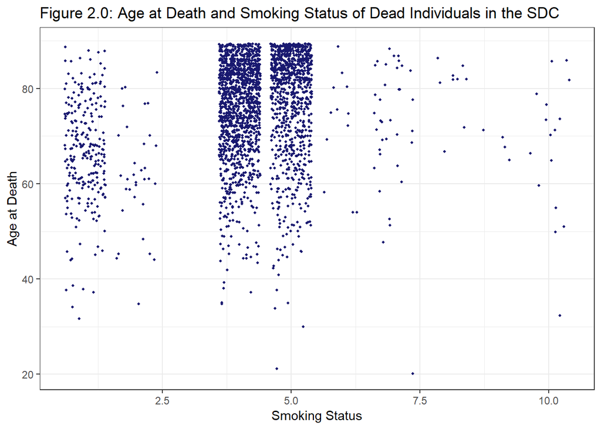

```r
ggplot(Sanford_dead, aes(Sanford_dead$SmokingStatus, Sanford_dead$Age)) + geom_jitter(color = "midnightblue", size = 0.75) + theme_bw() + labs(title = "Figure 2.0: Age at Death and Smoking Status of Dead Individuals in the SDC", x = "Smoking Status", y = "Age at Death")
```

#### Chunk 6: Created a dataset of all living individuals in the Sanford Data Collaborative. Checked if a correlation existed between Age and SmokingStatus among living individuals.

```r
Sanford_live <- Sanford_data[which(Sanford_data$Status == "Alive"), names(Sanford_data) %in% c("ID", "Sex","Age","BMI","Diabetes","SmokingStatus")]
cor.test (x = Sanford_live$Age, y = Sanford_live$SmokingStatus, method = 'pearson')
```

```
##
##  Pearson's product-moment correlation
##
## data:  Sanford_live$Age and Sanford_live$SmokingStatus
## t = 45.696, df = 145770, p-value < 2.2e-16
## alternative hypothesis: true correlation is not equal to 0
## 95 percent confidence interval:
##  0.1137748 0.1238968
## sample estimates:
##       cor
## 0.1188389
```

#### Chunk 7: Created histograms displaying the age distribution among living, deceased, and all members of the SDC.

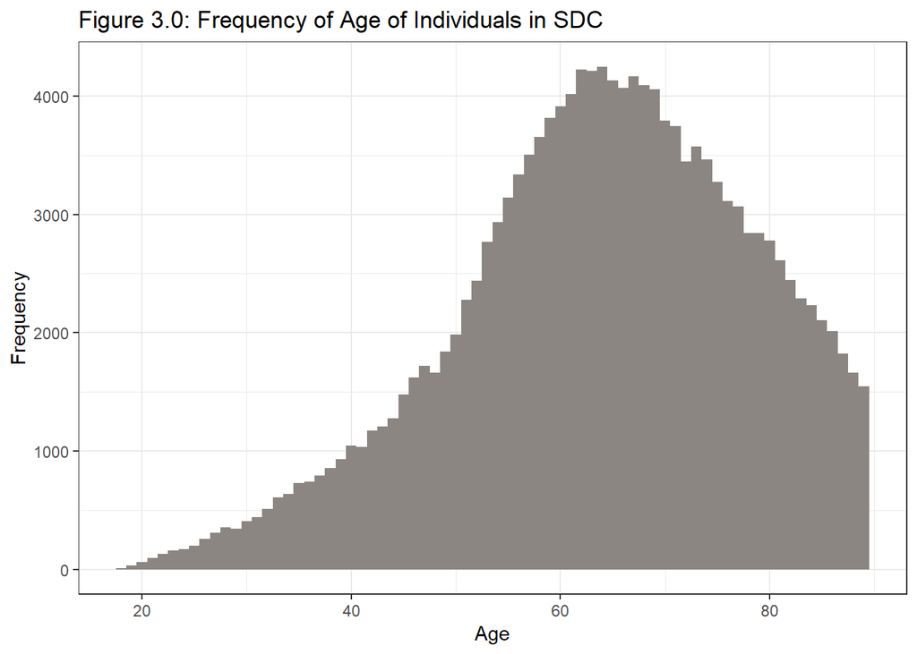

```r
ggplot(Sanford_data, aes(Sanford_data$Age)) + geom_histogram(binwidth = 1, fill = "seashell4") + theme_bw() + labs(title = "Figure 3.0: Frequency of Age of Individuals in SDC", x = "Age", y = "Frequency")
```

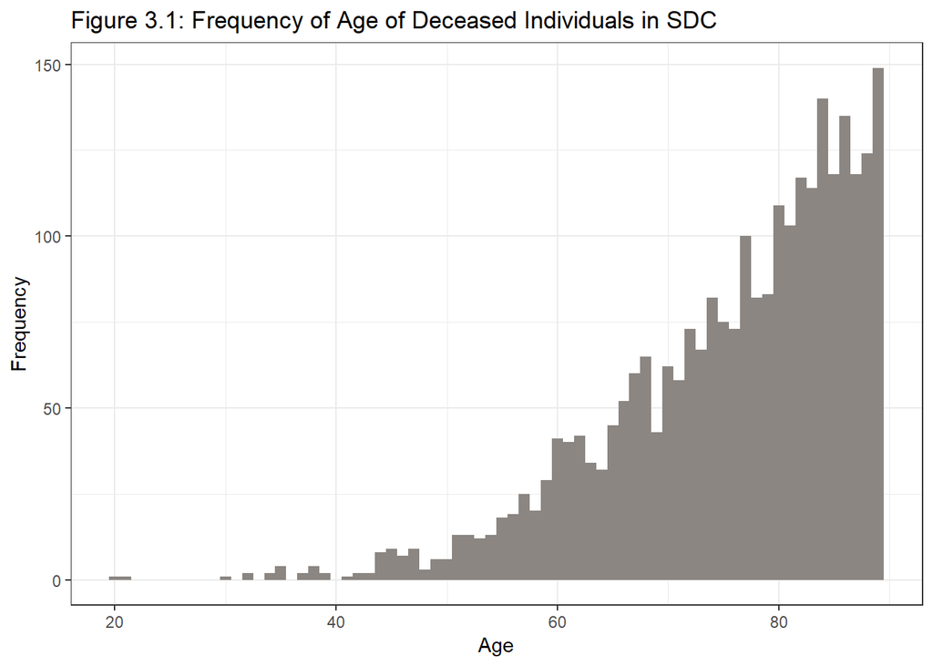

```r
ggplot(Sanford_dead, aes(Sanford_dead$Age)) + geom_histogram(binwidth = 1, fill = "seashell4") + theme_bw() + labs(title = "Figure 3.1: Frequency of Age of Deceased Individuals in SDC", x = "Age", y = "Frequency")
```

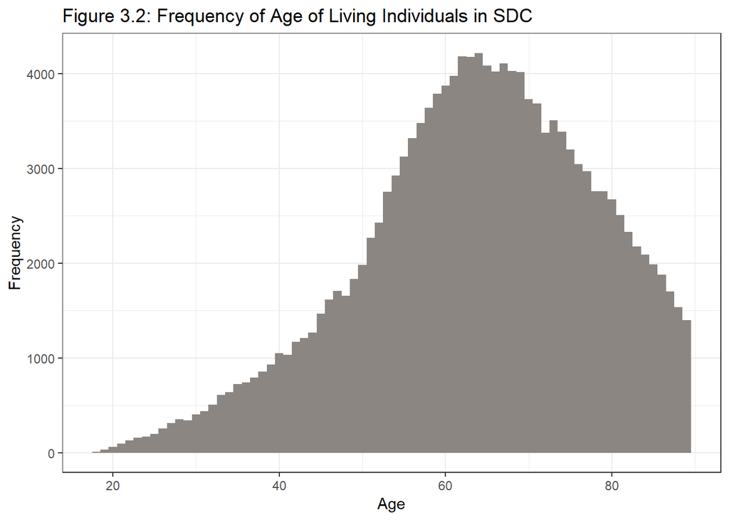

```r
ggplot(Sanford_live, aes(Sanford_live$Age)) + geom_histogram(binwidth = 1, fill = "seashell4") + theme_bw() + labs(title = "Figure 3.2: Frequency of Age of Living Individuals in SDC", x = "Age", y = "Frequency")
```

#### Chunk 8: A Histogram of YearBorn is just a mirror image of Age in the living population.

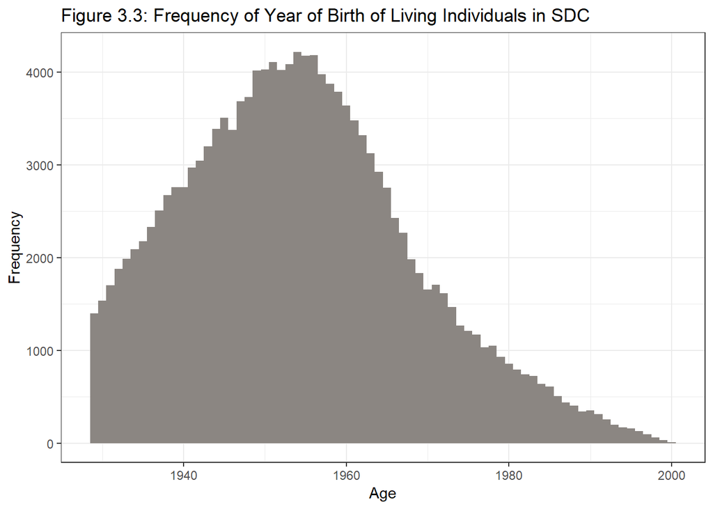

```r
Sanford_live$YearBorn = 2018 - Sanford_live$Age
ggplot(Sanford_live, aes(Sanford_live$YearBorn)) + geom_histogram(binwidth = 1, fill = "seashell4") + theme_bw() + labs(title = "Figure 3.3: Frequency of Year of Birth of Living Individuals in SDC", x = "Age", y = "Frequency")
```

#### Chunk 9: Created dataset SmokingHistory showing year born and average smoking status. Line graph showing year born versus average smoking status among the living population.

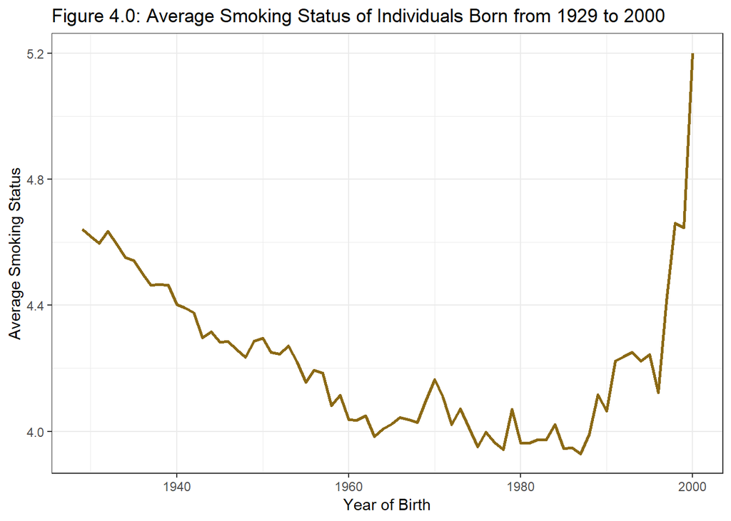

```r
SmokingHistory = aggregate(Sanford_live$SmokingStatus, by = list(Sanford_live$YearBorn), FUN = mean)
names(SmokingHistory) <- c("YearBorn", "AverageSmokingStatus")
ggplot(SmokingHistory, aes(SmokingHistory$YearBorn, SmokingHistory$AverageSmokingStatus)) + geom_line(color = "goldenrod4", size = 1) +theme_bw() + labs(title = "Figure 4.0: Average Smoking Status of Individuals Born from 1929 to 2000", x = "Year of Birth", y = "Average Smoking Status")
```

```r
cor.test (x = SmokingHistory$YearBorn, y = SmokingHistory$AverageSmokingStatus, method = 'pearson')
```

```
##
##  Pearson's product-moment correlation
##
## data:  SmokingHistory$YearBorn and SmokingHistory$AverageSmokingStatus
## t = -3.3678, df = 70, p-value = 0.001235
## alternative hypothesis: true correlation is not equal to 0
## 95 percent confidence interval:
##  -0.5569019 -0.1551636
## sample estimates:
##        cor
## -0.3734094
```

## Discussion

#### The lack of correlation of BMI with other factors may suggest that this metric is inaccurate, as suggested by Bigaard et al. in 2012. BMI does not accurately portray a person’s obesity or health, and other measurements might form a more complete picture of a person’s obesity status. These other measurements would be essential in further research into a correlation between obesity and life expectancy.

#### The generational decline in smoking observed in Figure 4.0 aligns with reports of declining smoking rates (Ny et al., 2014). This decline might explain the odd correlation between smoking status and life expectancy. Older individuals grew up with less awareness of the negative effects of smoking, and their views on the subject might differ from younger individuals. Thus, older patients might be more likely to have smoked for much of their lives due to a lack of educational awareness about the dangers of smoking.

#### Further research must account for generational differences in smoking rates as well as the negative skew in the SDC. To account for these effects, a dataset must be used with more than 3,663 deceased individuals, preferably one with a more even distribution of age of death. A perfect distribution is likely unattainable, as humans can die 60 years before the median age of death, but will not live 60 years past. However, the information of more individuals who died earlier than expected would be helpful.

## References

#### Albanes, D., Jones, D.Y., Micozzi, M.S., Mattson, M.E. (1987). Associations between smoking and body weight in the US population: analysis of NHANES II. American Journal of Public Health, 77(4), 439-444.

#### Bigaard, J., Tjonneland, A., Thomsen, B.L., Overvad, K., Heitmann, B.L., & Sorensen, T.I.A. (2012). Waist Circumference, BMI, Smoking, and Mortality in Middle-Aged Men and Women. Wiley Obesity Research, 11(7).

#### Ferrucci, L., Izmirlian, G., Leveille, S., Phillips, C.L., Corti, M., Brock, D.B., Guralnik, J.M. (1999). Smoking, Physical Activity, and Active Life Expectancy. American Journal of Epidemiology, 149(7), 645-653.

#### Ng, M., Freeman, M.K., Fleming, T.D., et al. (2014). Smoking Prevalence and Cigarette Consumption in 187 countries, 1980-2012. Journal of the American Medical Association, 311(2), 183-192.

#### Sakata, R., McGale, P., Grant, E.J., Ozasa, K., Peto, R., & Darby, S.C. (2012). Impact of smoking on morality and life expectancy in Japanese smokers: a prospective cohort study. BMJ.

#### Stewart, S.T., Cutler, D.M., Allison, B.R. (2009). Forecasting the Effects of Obesity and Smoking on U.S. Life Expectancy. The New England Journal of Medicine, 361, 2252-2260.

#### Streppel, M.T., Boshuizen, H.C., Ocke, M.C., Kok, F.J., Kromhout, D. (2007). Mortality and life expectancy in relation to long-term cigarette, cigar and pipe smoking: The Zutphen Study. Tobacco Control, 16(2).

#### Van Baal, P.H.M., Hoogenveen, R.T., De Wit, A.G., Boshuizen, H.C. (2006). Estimating health-adjusted life expectancy conditional on risk factors: results for smoking and obesity. Population Health Metrics, 4(14).